# Other methods in gene set analysis

Siying Huang (E0482362), Biomarker statistics team

created: 2023-06-08 , updated (2023-07-05)

```r
library(here)
library(dplyr)
library(ggplot2)
source(file.path(here(), "src/utils.R"))
```

```r
rst <- readRDS(file.path(here(), "data/de_rst.rds"))
rownames(rst) <- rst$ID
# gene_ids <- readRDS(file.path(here(), "data/gene_id.rds"))
```

# Other methods

[figure not shown]

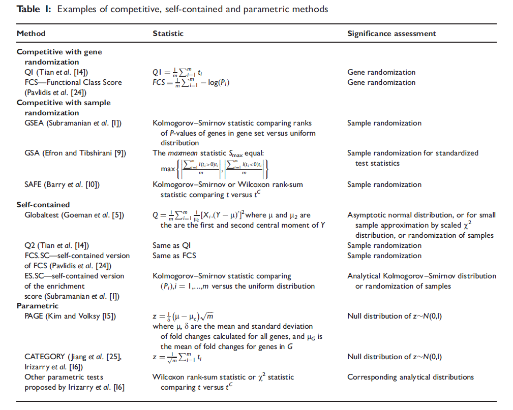

These methods are challengers of the GSEA methods that first proposed by Mootha et al. (2003). Many of them critize the Kolmogorov–Smirnov test used for enrichment score are not sensitive. And all of these alternatives claims that they have better power than K-S test in GSEA. The others aim to solve the issue of intercorrelation among genes within the same or close biological process.

- [maxmean statsitics, restandardization](https://arxiv.org/pdf/math/0610667.pdf) Efron and Tibshirani (2007)
- [mean shift test](https://www.pnas.org/doi/10.1073/pnas.0506577102) Tian et al. (2005) , Irizarry et al. (2009)
- [PAGE](https://bmcbioinformatics.biomedcentral.com/articles/10.1186/1471-2105-6-144) Kim and Volsky (2005)
- [SAFE](https://academic.oup.com/bioinformatics/article/21/9/1943/408983?login=true) Barry, Nobel, and Wright (2005)
- [Camera](https://academic.oup.com/nar/article/40/17/e133/2411151?login=true) Wu and Smyth (2012)
- [ROAST](https://academic.oup.com/bioinformatics/article/26/17/2176/200022?login=true) Wu et al. (2010)

Here I use the smoking study to illustrate the ideas of these methods. Instead of choosing a particular biological pathway, I choose these pathway with intention to evaluate the property of each method.

# Gene set selection

The results for the DEG analysis were sorted based on p values. Here I generate three gene sets:

- geneset 1: randomly select 10 genes
- geneset 2: select 50 genes that are not differentially expressed
- geneset 3: select top 30 differentially expressed genes

```r
set.seed(123)
gs1 <- sample(rst$ID, 10)
gs2 <- sample(rst[rst$P.Value > 0.5, "ID"], 50)
gs3 <- head(rst$ID, 30)
```

Of note, in gene set 3, 50% of the genes are up-regulated, 50% of genes are down regulated.

```
DOWN   UP
  15   15
```

## Comparison of the distributions of gene sets

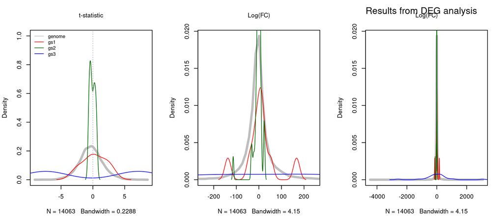

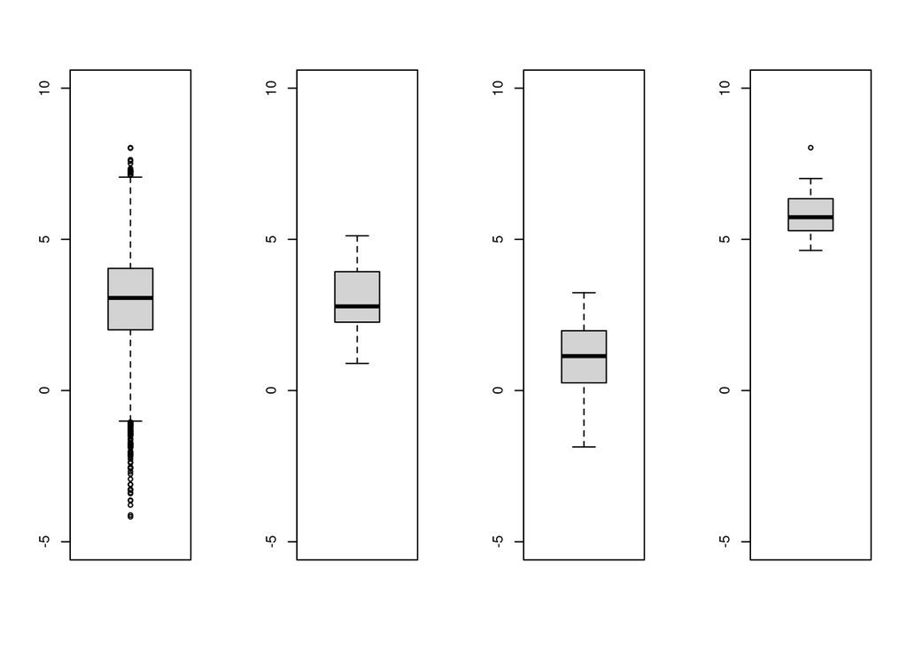

```r
par(mfrow = c(1, 4))
boxplot(log(rst$logFC),
  ylim = c(-5, 10),
  at = 4
)
boxplot(log(rst[gs1, "logFC"]),
  ylim = c(-5, 10)
)
boxplot(log(rst[gs2, "logFC"]), ylim = c(-5, 10))
boxplot(log(rst[gs3, "logFC"]), ylim = c(-5, 10))
```

## Parametric Analysis of Gene Set Enrichment (PAGE)

> PAGE calculates a Z score for a given gene set from a parameter such as **fold change** value between two experimental groups and infers statistical significance of the Z score against standard normal distribution. – Kim and Volsky (2005)

**Null hypothesis:** the distribution of the parameters for a given geneset follows normal distribution.

```r
m <- mean(rst$logFC)
s <- sd(rst$logFC)
sqrt(var(rst$logFC))
```

```
[1] 156.2509
```

```r
# calc z score

page <- function(data, gs, params ='logFC'){
  mn <- mean(data[,params])
  sd <- sd(data[,params])
  m_s <- mean(data[gs, params])
  m <- length(gs)
  z <- sqrt(m) * (mn - m_s) / sd
  c(z, pnorm(z))
}

page(rst, gs1)
```

```
[1] -0.2304856  0.4088572
```

```r
page(rst, gs2)
```

```
[1] -0.08333516  0.46679252
```

```r
page(rst, gs3)
```

```
[1] -0.9225926  0.1781098
```

## Mean shift methods

These are the challengers of K-S test in the GSEA. The first test: t-test or wilcoxon test, as gene set gets large it approximate Z distribution. $E_g^z= \sqrt{N_g}\bar{t}$ with $\bar{t}= 1/N_g\sum_{i \in A_g} t_i$

Tian et al. (2005) propose to estimate the significance of a particular gene set by constructiong null distribution using permutations.

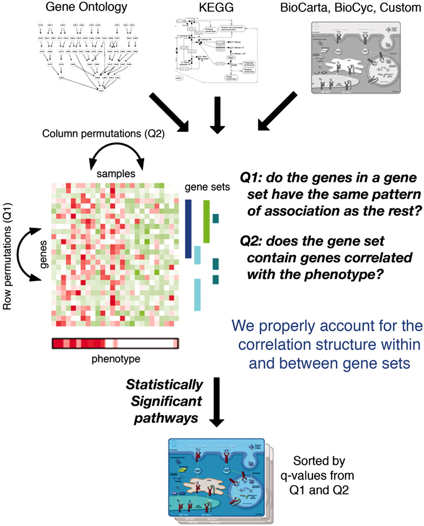

```r
m_gs1 <- mean(rst[gs1, "t"])
z_gs1 <- sqrt(length(gs1)) * m_gs1
pnorm(z_gs1, lower.tail = F)
```

```
[1] 0.2550601
```

```r
z_test(rst, gs2, "t")
```

```
[1] 0.6750309
```

```r
z_test(rst, gs3, "t")
```

```
[1] 0.7864247
```

Chi square test was proposed by Irizarry et al. (2009) to circumvent that the one-sample z test cannot detect the pathway where it contain half up-regulated, half-downregulated genes.

> A possible advantage of GSEA, i.e. the K-S test, over the one sample z-test is that the latter is specifically designed to identify gene sets with mean shifts and the K-S test is designed to find general difference in the cumulative distribution. In principle, we want to be able to detect gene sets for which some members are up-regulated and others are down-regulated. The z-test is not sensitive to this change as there is no shift in mean. We therefore, propose the use of another standard statistical test useful for detecting changes in scale: the χ2 test. – Irizarry et al. (2009)

$E_g^{X^2} = \frac{\sum_{i\in A_g}(t_i - \bar{t})^2 -(N_g -1) }{2(N_g -1)}$

```r
x2_gs1 <- (sum((rst[gs1, "t"] - m_gs1)^2) - (length(gs1) - 1)) / (2 * (length(gs1) - 1))

1 - pchisq(x2_gs1, df = length(gs1) - 1)
```

```
[1] 0.9986549
```

```r
pchisq(x2_gs1, df = 1)
```

```
[1] 0.7345517
```

```r
chisq_test <- function(t_vec, df = NULL) {
  if (is.null(df)) df <- length(t_vec) - 1
  t_bar <- mean(t_vec, na.rm = T)
  m <- length(t_vec) - 1
  numr <- sum((t_vec - t_bar)^2) - m
  x2 <- numr / (2 * m)
  print(x2)
  1 - pchisq(x2, df = df)
}

t_vec <- rst[gs3, "t"]
chisq_test(rst[gs1, "t"])
```

```
[1] 1.240118
```

```
[1] 0.9986549
```

```r
chisq_test(rst[gs2, "t"])
```

```
[1] -0.4162869
```

```
[1] 1
```

```r
chisq_test(rst[gs3, "t"])
```

```
[1] 27.12194
```

```
[1] 0.5651261
```

## Maxmean statistics and restarndardization

This method was proposed by Efron and Tibshirani (2007) and is available in the R package `GSA`.

```r
library(GSA)
expr <- readRDS(file.path(here(), "data/expr.rds"))
# I simplily removed the duplicated genes here. In practice removing
# duplicated genes should be given careful consideration.
expr <- expr[!duplicated(expr$IDENTIFIER), ] %>%
  `rownames<-`(NULL) %>%
  tibble::column_to_rownames("IDENTIFIER")%>%
  dplyr::select(-ID_REF)

pheno <- readRDS(file.path(here(), "data/pheno.rds")) %>%
  mutate(status = if_else(stress == "control", 1, 2)) %>%
  dplyr::select(status)
class(pheno)
GSA.func(
  as.matrix(log(expr)),
  pheno[, 1],
  genesets = list(gs1),
  genenames= rownames(expr), resp.type = "Two class unpaired"
)

summary(expr)

expr[gs2,]

x <- matrix(rnorm(1000 * 20), ncol = 20)
summary(x)
dd <- sample(1:1000, size = 100)
u <- matrix(2 * rnorm(100), ncol = 10, nrow = 100)
x[dd, 11:20] <- x[dd, 11:20] + u
y <- c(rep(1, 10), rep(2, 10))
genenames <- paste("g", 1:1000, sep = "")
# create some random gene sets
genesets <- vector("list", 50)
for (i in 1:50) {
  genesets[[i]] <- paste("g", sample(1:1000, size = 30), sep = "")
}
geneset.names <- paste("set", as.character(1:50), sep = "")
GSA.func.obj <- GSA.func(x, y, genenames = genenames, genesets = genesets, resp.type = "Two class unpaired")

str(GSA.func.obj)
```

[output not shown]

# Comparison of gene set analysis methods

[Comparison of gene set scoring methods for reproducible evaluation of multiple tuberculosis gene signatures](https://www.ncbi.nlm.nih.gov/pmc/articles/PMC9882404/)

## Reviews

- [Pathway Analysis: State of the Art](https://www.frontiersin.org/articles/10.3389/fphys.2015.00383/full) García-Campos, Espinal-Enríquez, and Hernández-Lemus (2015)
- [Analyzing gene expression data in terms of gene sets: methodological issues](https://academic.oup.com/bioinformatics/article/23/8/980/198511?login=true)
- [Gene set analysis methods: statistical models and methodological differences](https://academic.oup.com/bib/article/15/4/504/407653?login=true) Maciejewski (2014)
- The Statistical Properties of Gene-Set Analysis de Leeuw et al. (2016)
- Khatri, Sirota, and Butte (2012)
- Maleki et al. (2020)
- Maleki et al. (2019)
- Mathur et al. (2018)

## Reference

Barry, William T., Andrew B. Nobel, and Fred A. Wright. 2005. “Significance Analysis of Functional Categories in Gene Expression Studies: A Structured Permutation Approach.” *Bioinformatics* 21 (9): 1943–9. https://doi.org/10.1093/bioinformatics/bti260.

de Leeuw, Christiaan A., Benjamin M. Neale, Tom Heskes, and Danielle Posthuma. 2016. “The Statistical Properties of Gene-Set Analysis.” *Nature Reviews Genetics* 17 (6): 353–64. https://doi.org/10.1038/nrg.2016.29.

Efron, Bradley, and Robert Tibshirani. 2007. “On Testing the Significance of Sets of Genes.” *The Annals of Applied Statistics* 1 (1). https://doi.org/10.1214/07-AOAS101.

García-Campos, Miguel A., Jesús Espinal-Enríquez, and Enrique Hernández-Lemus. 2015. “Pathway Analysis: State of the Art.” *Frontiers in Physiology* 6.

Irizarry, Rafael A., Chi Wang, Yun Zhou, and Terence P. Speed. 2009. “Gene Set Enrichment Analysis Made Simple.” *Statistical Methods in Medical Research* 18 (6): 565–75. https://doi.org/10.1177/0962280209351908.

Khatri, Purvesh, Marina Sirota, and Atul J. Butte. 2012. “Ten Years of Pathway Analysis: Current Approaches and Outstanding Challenges.” *PLOS Computational Biology* 8 (2): e1002375. https://doi.org/10.1371/journal.pcbi.1002375.

Kim, Seon-Young, and David J. Volsky. 2005. “PAGE: Parametric Analysis of Gene Set Enrichment.” *BMC Bioinformatics* 6 (1): 144. https://doi.org/10.1186/1471-2105-6-144.

Maciejewski, Henryk. 2014. “Gene Set Analysis Methods: Statistical Models and Methodological Differences.” *Briefings in Bioinformatics* 15 (4): 504–18. https://doi.org/10.1093/bib/bbt002.

Maleki, Farhad, Katie Ovens, Daniel J. Hogan, and Anthony J. Kusalik. 2020. “Gene Set Analysis: Challenges, Opportunities, and Future Research.” *Frontiers in Genetics* 11.

Maleki, Farhad, Katie L Ovens, Elham Rezaei, Alan M Rosenberg, and Anthony J Kusalik. 2019. “Method Choice in Gene Set Analysis Has Important Consequences for Analysis Outcome,” 12.

Mathur, Ravi, Daniel Rotroff, Jun Ma, Ali Shojaie, and Alison Motsinger-Reif. 2018. “Gene Set Analysis Methods: A Systematic Comparison.” *BioData Mining* 11 (1): 8. https://doi.org/10.1186/s13040-018-0166-8.

Mootha, Vamsi K., Cecilia M. Lindgren, Karl-Fredrik Eriksson, Aravind Subramanian, Smita Sihag, Joseph Lehar, Pere Puigserver, et al. 2003. “PGC-1alpha-Responsive Genes Involved in Oxidative Phosphorylation Are Coordinately Downregulated in Human Diabetes.” *Nature Genetics* 34 (3): 267–73. https://doi.org/10.1038/ng1180.

Tian, Lu, Steven A. Greenberg, Sek Won Kong, Josiah Altschuler, Isaac S. Kohane, and Peter J. Park. 2005. “Discovering Statistically Significant Pathways in Expression Profiling Studies.” *Proceedings of the National Academy of Sciences* 102 (38): 13544–9. https://doi.org/10.1073/pnas.0506577102.

Wu, Di, Elgene Lim, François Vaillant, Marie-Liesse Asselin-Labat, Jane E. Visvader, and Gordon K. Smyth. 2010. “ROAST: Rotation Gene Set Tests for Complex Microarray Experiments.” *Bioinformatics* 26 (17): 2176–82. https://doi.org/10.1093/bioinformatics/btq401.

Wu, Di, and Gordon K. Smyth. 2012. “Camera: A Competitive Gene Set Test Accounting for Inter-Gene Correlation.” *Nucleic Acids Research* 40 (17): e133. https://doi.org/10.1093/nar/gks461.